# CH08P63 One Way ANOVA

crl

April 24, 2018

```r
knitr::opts_chunk$set(echo = TRUE)
```

# QCI Six Sigma Primer

## One Way ANOVA

### Overview

*One Way ANOVA* is used to compare means for three or more groups.

- Recall that the Student-t test compares means of two groups.
- Why not just use multiple t-tests between each pair of means?
  - Because each test has a Type 1 error (alpha, often 0.05).
  - If doing multiple comparisons each test has it’s own Type 1 error.
  - Doing multiple tests inflates the Type 1 error across the experiment as a whole.
  - ANOVA can compensate for this.

Various types of ANOVA

- One Way ANOVA - one factor with three or more groups.
- Two Way ANOVA - two factors, each with multiple groups.
- Factorial ANOVA - multiple factors, along with interaction terms.

Other Concepts

- Fixed effects ANOVA (what most people know) - studies the differences in means
- Random effects ANOVA (and Mixed Effects) - studies components of variance

### Read More

[One Way ANOVA Wikipedia](https://en.wikipedia.org/wiki/One-way_analysis_of_variance)

[One Way ANOVA NIST](https://www.itl.nist.gov/div898/handbook/ppc/section2/ppc231.htm)

[Examples here](http://www.sthda.com/english/wiki/one-way-anova-test-in-r)

[ANOVA assumptions STHDA](http://www.sthda.com/english/wiki/one-way-anova-test-in-r#check-anova-assumptions-test-validity)

[ANOVA assumptions Quick R](https://www.statmethods.net/stats/anovaAssumptions.html)

### More

[One Way ANOVA Demo](https://crlstatistics.shinyapps.io/anova_demo/)

[Presentation](https://docs.google.com/presentation/d/1W4IdxwG_raXJ_NotgdwgyplsfShOQqOzJYarinLmMXw/edit?usp=sharing)

[Variance Partitioning](https://drive.google.com/file/d/1_JmnMcrZqlPW4glg7GvGE0u4b9Uwn0kK/view?usp=sharing)

### ANOVA Hypotheses

The null hypothesis H0 is that there is no difference between any of the sample means.  
The alternate hypothesis HA is that there is a difference between at least two of the sample means.

# Analysis

## Load Packages

```r
library(tidyverse)
library(car)
library(lmtest)
library(vrtest)
```

## Primer Example

### Prepare the data set.

Often we use stringsAsFactors = FALSE.  
In this case, with ANOVA, the categorical variable should be a factor, therefore we use the default stringsAsFactors = TRUE.

```r
dat <- read.csv('data/ch08p63-one-way-anova.csv')
glimpse(dat)
```

```
## Observations: 15
## Variables: 2
## $ machine <fct> A, A, A, A, A, B, B, B, B, B, C, C, C, C, C
## $ reading <int> 5, 7, 6, 7, 6, 2, 0, 1, -2, 2, 1, 0, -2, -3, 0
```

## Look at the data

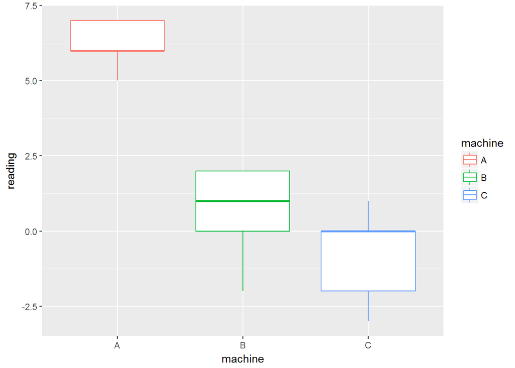

```r
ggplot(data = dat, aes(x = machine, y = reading, color = machine)) +
  geom_boxplot()
```

From just a boxplot it is not always easy to know if sample means are different.  
This is why we also use ANOVA.

## One Way ANOVA

### Conducting the ANOVA analysis

```r
fit <- aov(reading ~ machine, data = dat)
summary(fit)
```

```
##             Df Sum Sq Mean Sq F value   Pr(>F)
## machine      2  137.2   68.60   33.19 1.29e-05 ***
## Residuals   12   24.8    2.07
## ---
## Signif. codes:  0 '***' 0.001 '**' 0.01 '*' 0.05 '.' 0.1 ' ' 1
```

The p-value [Pr(>F)] for ‘machine’ tells us if there is a difference between at least two (or more) means. What it does not tell us is between which pairs of means the difference(s) exist. For this we can use contrasts or post-hoc tests.

Comparing results to the Primer:

- SST matches the R output (137.2)
- SSE matches the R output (24.8)
- F value for machine matches the R output (33.2)
- Degrees of Freedom match the R output (2, 12)

The critical value of F with df = (2, 12) at alpha = 0.05 is 3.89  
The calculated value of F (33.2) is larger than F critical.  
Therefore we reject H0 that there is no difference between any of the sample means.

### How can we find out where the differences exist?

[Stat Notes - ANOVA Post-Hoc Tests](https://drive.google.com/file/d/1hs32aXJ_Nqc0mBeE9qv1yvcTYwwfX8Bg/view?usp=sharing)

```r
TukeyHSD(fit)
```

```
##   Tukey multiple comparisons of means
##     95% family-wise confidence level
##
## Fit: aov(formula = reading ~ machine, data = dat)
##
## $machine
##     diff       lwr       upr     p adj
## B-A -5.6 -8.025654 -3.174346 0.0001337
## C-A -7.0 -9.425654 -4.574346 0.0000154
## C-B -1.4 -3.825654  1.025654 0.3080175
```

### Plot of means and confidence intervals

```
## geom_path: Each group consists of only one observation. Do you need to
## adjust the group aesthetic?
```

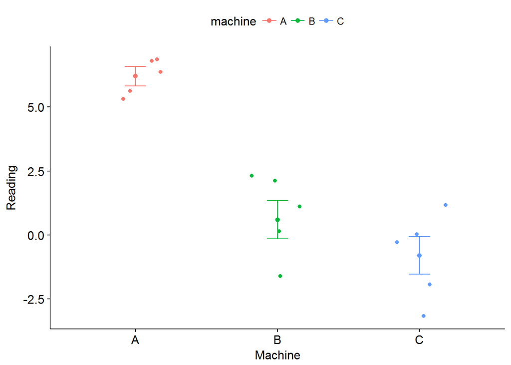

```r
# Mean plots
# Plot weight by group
# Add error bars: mean_se
# (other values include: mean_sd, mean_ci, median_iqr, ....)
library(ggpubr)
ggline(dat, x = "machine", y = "reading",
       add = c("mean_se", "jitter"),
       order = c("A", "B", "C"),
       ylab = "Reading", xlab = "Machine",
       color = 'machine')
```

## Model Diagnostics

Testing the assumptions behind the ANOVA method.

### Plot fitted vs residuals

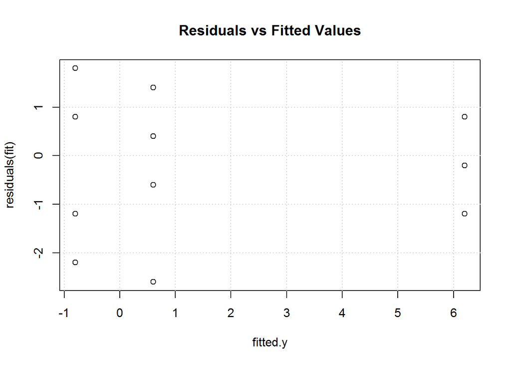

```r
fitted.y = fit$fitted


# plot residuals vs fitted
plot(fitted.y, residuals(fit))
title("Residuals vs Fitted Values")
grid()
```

### Normality diagnostics

Test normality using Shapiro-Wilks test

```r
res.shapiro = shapiro.test(residuals(fit))

print(res.shapiro)
```

```
##
##  Shapiro-Wilk normality test
##
## data:  residuals(fit)
## W = 0.92963, p-value = 0.2694
```

```r
if (res.shapiro$p.value < 0.05){
  print("Nonnormally distributed residuals")} else {
    print("Normally distributed residuals")
  }
```

```
## [1] "Normally distributed residuals"
```

Normality plot of residuals

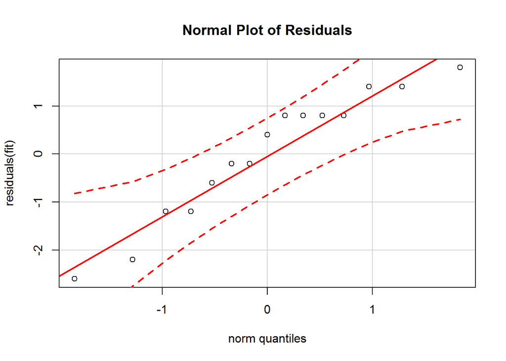

```r
qqPlot(residuals(fit), main = "Normal Plot of Residuals")
```

### Family of influence measures

```r
infl.fit = influence.measures(fit)

print(summary(infl.fit))
```

```
## Potentially influential observations of
##   aov(formula = reading ~ machine, data = dat) :
## NONE
## numeric(0)
```

```r
id.infl = which(apply(infl.fit$is.inf, 1, any))

print("Most influential observations:")
```

```
## [1] "Most influential observations:"
```

```r
print(id.infl)
```

```
## named integer(0)
```

### Cook’s Distance

```r
# find unusual Cooks Distance

fit.cook = cooks.distance(fit)

print("Influential Cooks D")
```

```
## [1] "Influential Cooks D"
```

```r
print(which(fit.cook > 3*mean(fit.cook)))
```

```
## 9
## 9
```

### Plot Cook’s diagnostics

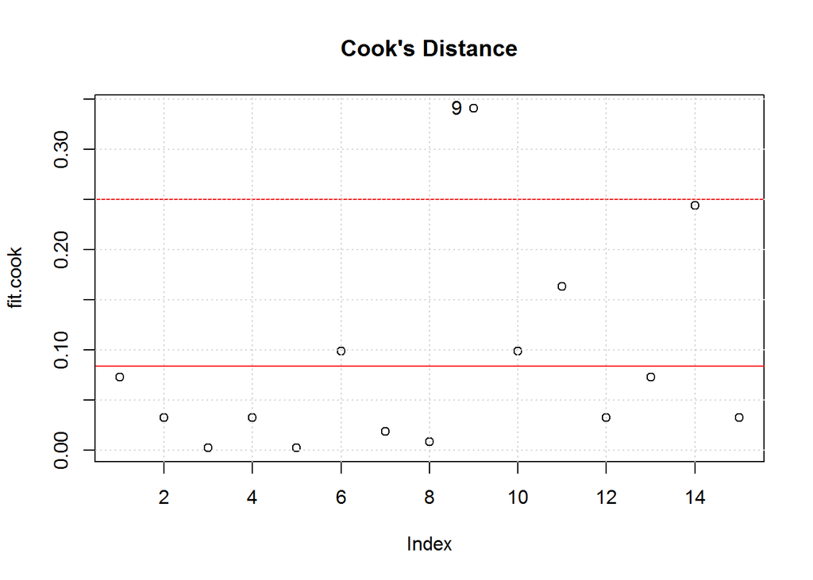

```r
fit.cook = cooks.distance(fit)

id.c = which(fit.cook > 3*mean(fit.cook))

# plot Cooks Distance
plot(fit.cook)
abline(h = c(1,3)*mean(fit.cook), col = 2)
title("Cook's Distance")
grid()

if (length(id.c) > 0){ text(id.c, fit.cook[id.c], rownames(dat)[id.c], pos = 2, xpd = TRUE) }
```

### Print studentized residuals diagnostics

```r
# STUDENTIZED RESIDUALS
fit.studres = rstudent(fit)

print("Noteworthy studentized residuals")
```

```
## [1] "Noteworthy studentized residuals"
```

```r
print(which(abs(fit.studres) > 3))
```

```
## named integer(0)
```

### Plot studentized residuals diagnostics

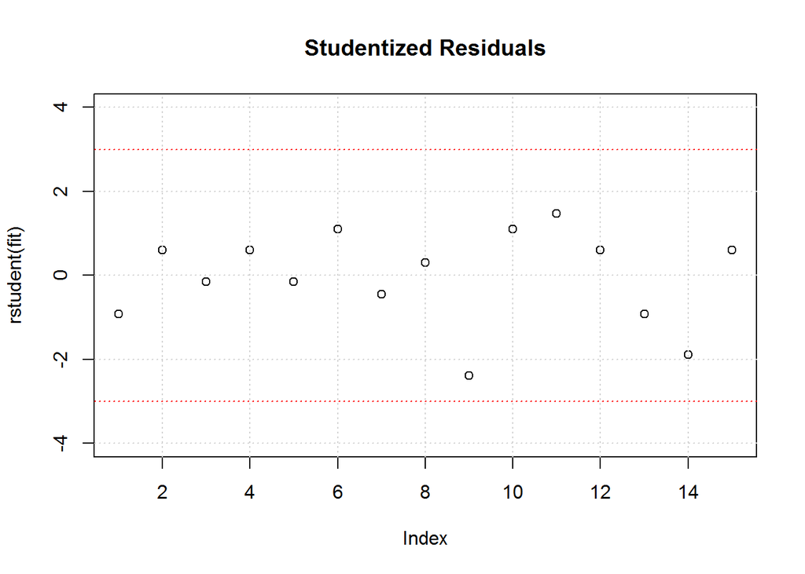

```r
fit.studres = rstudent(fit)

id.sr = which(abs(fit.studres) > 3)

# plot studentized residuals
plot(rstudent(fit), ylim = c(-4,4))
abline(h = c(-3,+3), col = 'red', lty = 3)
title('Studentized Residuals')
grid()
```

```r
if (length(id.sr) > 0){ text(id.sr, fit.studres[id.sr], rownames(dat)[id.sr], pos = 2, xpd = TRUE) }
```

### Print leverage diagnostics

```r
# LEVERAGE based on HAT MATRIX
fit.hat = hatvalues(fit)

print("Noteworthy leverage values")
```

```
## [1] "Noteworthy leverage values"
```

```r
print(which(fit.hat > 3*mean(fit.hat)))
```

```
## named integer(0)
```

### Plot leverage diagnostics

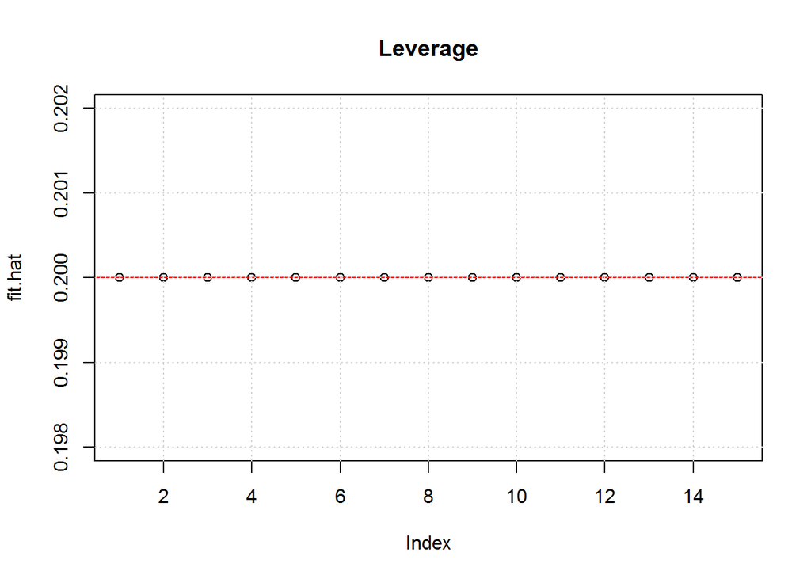

```r
fit.hat = hatvalues(fit)

id.h = which(fit.hat > 3*mean(fit.hat))


# plot leverage
plot(fit.hat)
abline(h = c(1,3)*mean(fit.hat), col = 2)
title('Leverage')
grid()
```

```r
if (length(id.h) > 0){ text(id.h, fit.hat[id.h], rownames(dat)[id.h], pos = 2, xpd = TRUE) }
```

### Print functional form diagnostics

```r
# test for functional form
# conditional mean of residuals equal to zero
# using the RESET test

res.fform = resettest(fit)

if (res.fform$p.value < 0.05){
  print("Functional Form Misspecified [E(e|X) <> 0]")} else {
    print("Functional Form Adequate [E(e|X) = 0]")
  }
```

```
## [1] "Functional Form Adequate [E(e|X) = 0]"
```

### Print constant variance (of residuals) diagnostics

```r
# test for heteroskedasticity
# using the Breusch-Pagan test

res.bp = bptest(fit)
res.bp$p.value
```

```
##        BP
## 0.2754631
```

```r
if (res.bp$p.value < 0.05){
  print("Residuals have NON-constant variance")} else {
    print("Residuals have constant variance")
  }
```

```
## [1] "Residuals have constant variance"
```

Levene’s test for equal variances

```r
leveneTest(reading ~ machine, data = dat)
```

```
## Levene's Test for Homogeneity of Variance (center = median)
##       Df F value Pr(>F)
## group  2  0.5625 0.5841
##       12
```

## Nonparametric alternative to One Way ANOVA

### Kruskal-Wallis test

```r
kruskal.test(reading ~ machine, data = dat)
```

```
##
##  Kruskal-Wallis rank sum test
##
## data:  reading by machine
## Kruskal-Wallis chi-squared = 10.387, df = 2, p-value = 0.005553
```